# Parametric Regression Discontinuity Analysis

Yelsh Gebreselassie

2022-09-21

```r
library(tidyverse)
library(broom)
library(rdrobust)
library(rddensity)
library(modelsummary)

tutoring <- read.csv("data/tutoring_program.csv")
attach(tutoring)
```

# Step 1: Determine if the process of assigning treatment is rule based

- We know if a student is assigned to a tutoring program based on certain rule if and only if we are familiar with the research process and the data. Looking at the dataset, we can see that only students who scored less that 70 are assigned to tutoring.

# Step 2: Determine if the design in fuzzy or sharp

- This is to determine if, for example, a student who scored > 70 is using tutoring or a student who scored < 70 is not assigned to tutoring.

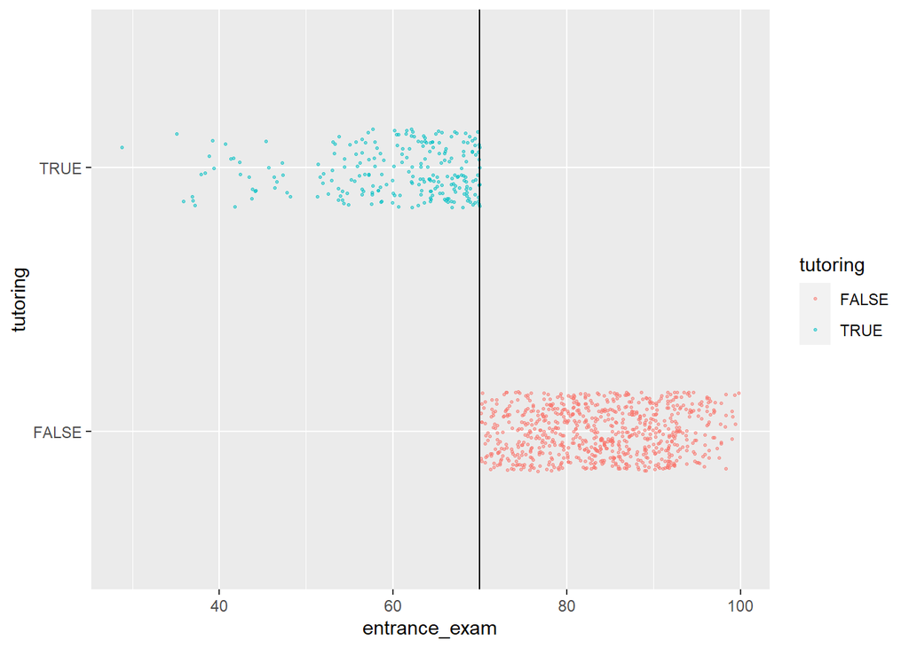

```r
ggplot(data = tutoring,
       mapping = aes(x = entrance_exam, y = tutoring, color = tutoring)) +
  geom_point(size = 0.5, alpha = 0.5,
             position = position_jitter(width = 0, height = 0.15), seed = 1234) +
  geom_vline(xintercept = 70)
```

- We can see above that the line looks sharp. It doesn’t look like anyone who scored above 70 is using tutoring or anyone who scored below 70 not using tutoring. We can also confirm this result numerically.

```r
tutoring %>%
  group_by(tutoring, entrance_exam > 70) %>%
  summarize(count =n())
```

```
## # A tibble: 2 × 3
## # Groups:   tutoring [2]
##   tutoring `entrance_exam > 70` count
##   <lgl>    <lgl>                <int>
## 1 FALSE    TRUE                   759
## 2 TRUE     FALSE                  241
```

- We can see that all who have scored below 70 (241 students) have been assigned to tutoring and those who scored above 70 (759 students) have not been assigned to tutoring.

# Step 3: Check for discontinuity in running variable around cutpoint

- This is to see if anyone is manipulating access to the entrance exam. For example, we need to make sure no one is purposely scoring a little over 70 to not be enrolled in the tutoring program or scoring just below 70 so they can be enrolled in tutoring.

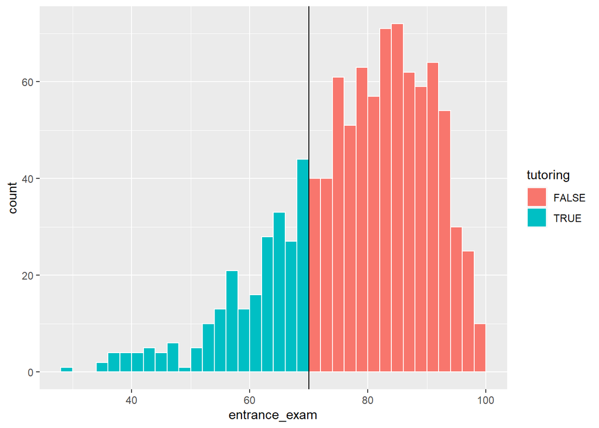

```r
ggplot(tutoring, aes(x = entrance_exam, fill = tutoring)) +
  geom_histogram(binwidth = 2, boundary = 70, color = "white") +
  geom_vline(xintercept = 70)
```

- There is a smooth transition at the cutoff point. We don’t, for example, observe many students just to the left of the cutoff point and then a significant drop after. We can test this more officially using McCrary desnsity test.

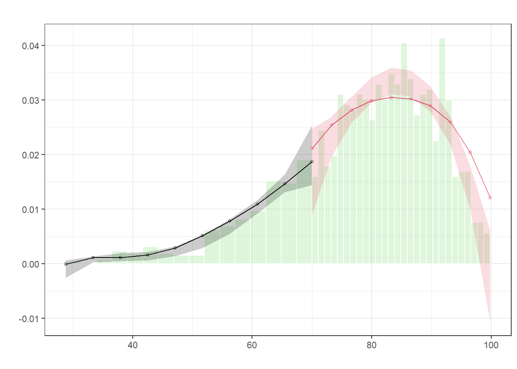

[output not shown]

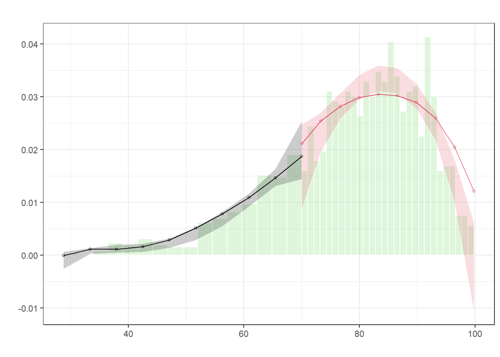

```r
rdplotdensity(rdd = rddensity(entrance_exam, c = 70),
              X = entrance_exam,
              type = "both")
```

- We can see that there is some gap but it is within the confidence interval on both sides.

# Step 4: Check for discontinuity in outcome across running variable.

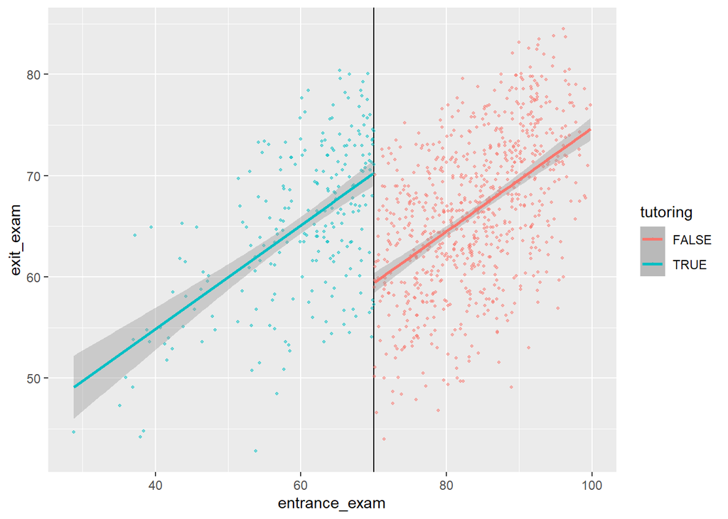

```r
ggplot(tutoring, aes(x = entrance_exam, y = exit_exam, color = tutoring)) +
  geom_vline(xintercept = 70) +
  geom_point(size = 0.75, alpha = 0.5) +
  geom_smooth(data = filter(tutoring, entrance_exam < 70), method = lm) +
  geom_smooth(data = filter(tutoring, entrance_exam > 70), method = lm)
```

Next we measure the gap.

# Step 5: Measure the size of the effect

Parametric measurement

```r
tutoring_centered <- tutoring %>%
  mutate(entrance_centered = entrance_exam - 70)
```

This will produce a new dataset called tutoring_centered with a new variable or column entrance_centered which shows how many points above or below a student scored.

Then we can run a regression model to measure the gap.

```r
model_simple <- lm(exit_exam ~ entrance_centered + tutoring,
                   data = tutoring_centered)
tidy(model_simple)
```

```
## # A tibble: 3 × 5
##   term              estimate std.error statistic  p.value
##   <chr>                <dbl>     <dbl>     <dbl>    <dbl>
## 1 (Intercept)         59.4      0.442      134.  0
## 2 entrance_centered    0.510    0.0269      18.9 1.40e-68
## 3 tutoringTRUE        10.8      0.800       13.5 3.12e-38
```

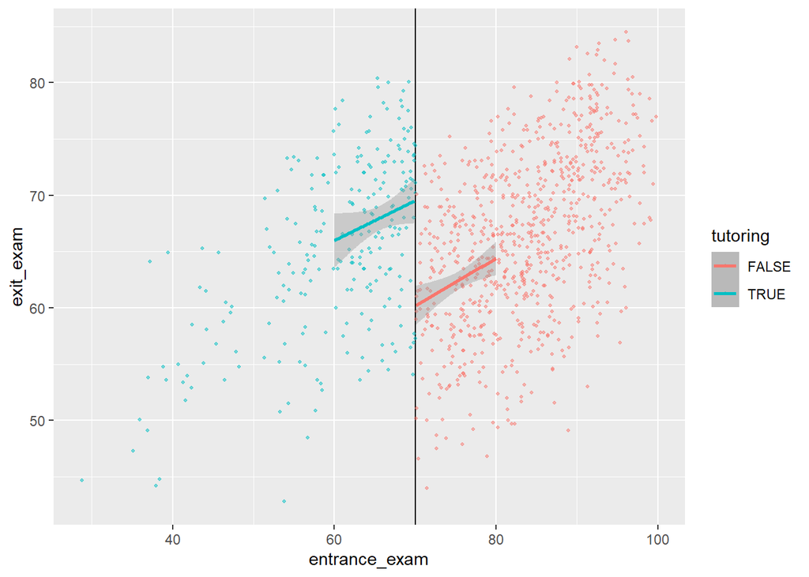

```r
ggplot(tutoring, aes(x = entrance_exam, y = exit_exam, color = tutoring)) +
  geom_vline(xintercept = 70) +
  geom_point(size = 0.75, alpha = 0.5) +
  geom_smooth(data = filter(tutoring,
                            entrance_exam < 70,
                            entrance_exam >=60),
              method = "lm") +
  geom_smooth(data = filter(tutoring,
                            entrance_exam > 70,
                            entrance_exam <=80),
              method = "lm")
```

```r
model_bw10 <- lm(exit_exam ~ entrance_centered + tutoring,
                   data = filter(tutoring_centered,
                                 entrance_centered <= 10,
                                 entrance_centered >= -10))
tidy(model_bw10)
```

```
## # A tibble: 3 × 5
##   term              estimate std.error statistic   p.value
##   <chr>                <dbl>     <dbl>     <dbl>     <dbl>
## 1 (Intercept)         60.4       0.752     80.3  2.99e-249
## 2 entrance_centered    0.388     0.114      3.40 7.45e-  4
## 3 tutoringTRUE         9.27      1.31       7.09 6.27e- 12
```

```r
model_bw5 <- lm(exit_exam ~ entrance_centered + tutoring,
                   data = filter(tutoring_centered,
                                 entrance_centered <= 5,
                                 entrance_centered >= -5))
tidy(model_bw5)
```

```
## # A tibble: 3 × 5
##   term              estimate std.error statistic   p.value
##   <chr>                <dbl>     <dbl>     <dbl>     <dbl>
## 1 (Intercept)         60.6       1.12      54.3  4.78e-118
## 2 entrance_centered    0.380     0.331      1.15 2.53e-  1
## 3 tutoringTRUE         9.12      1.91       4.77 3.66e-  6
```

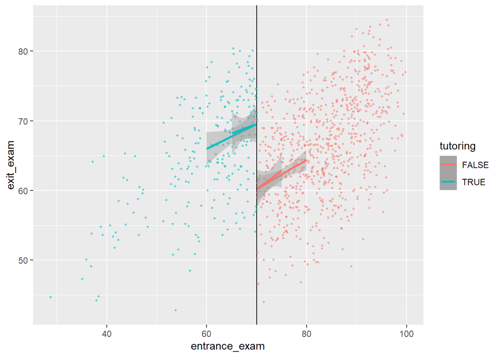

```r
ggplot(tutoring, aes(x = entrance_exam, y = exit_exam, color = tutoring)) +
  geom_vline(xintercept = 70) +
  geom_point(size = 0.75, alpha = 0.5) +
  geom_smooth(data = filter(tutoring,
                            entrance_exam < 70,
                            entrance_exam >=60),
              method = "lm") +
  geom_smooth(data = filter(tutoring,
                            entrance_exam > 70,
                            entrance_exam <=80),
              method = "lm") +
  geom_smooth(data = filter(tutoring,
                            entrance_exam < 70,
                            entrance_exam >=65),
              method = "lm") +
  geom_smooth(data = filter(tutoring,
                            entrance_exam > 70,
                            entrance_exam <=75),
              method = "lm")
```

# Step 6: Compare all the effects

```r
modelsummary(list(model_simple, model_bw10, model_bw5))
```

|  | Model 1 | Model 2 | Model 3 |
| --- | --- | --- | --- |
| (Intercept) | 59.411 | 60.377 | 60.631 |
|  | (0.442) | (0.752) | (1.117) |
| entrance_centered | 0.510 | 0.388 | 0.380 |
|  | (0.027) | (0.114) | (0.331) |
| tutoringTRUE | 10.800 | 9.273 | 9.122 |
|  | (0.800) | (1.309) | (1.912) |
| Num.Obs. | 1000 | 404 | 194 |
| R2 | 0.268 | 0.162 | 0.222 |
| R2 Adj. | 0.267 | 0.158 | 0.214 |
| AIC | 6595.3 | 2663.5 | 1303.1 |
| BIC | 6615.0 | 2679.5 | 1316.2 |
| Log.Lik. | −3293.663 | −1327.755 | −647.567 |
| RMSE | 6.52 | 6.47 | 6.81 |